# Thursday NIMBLE

Mike Li, Morgan Kain

09:35 26 November 2015

```r
library(knitr)
opts_knit$set(root.dir = "/Users/Morgan/Documents/Research/McMaster/Modeling_Work/Mike_Lunchbox/My_edits/lunchbox")
options(mc.cores = parallel::detectCores())
#opts_chunk$set(cache = TRUE)
```

## NIMBLE: Numerical Inference for statistical Models for Bayesian and Likelihood Estimation

NIMBLE is built in R but compiles your models and algorithms using C++ for speed  
NIMBLE is most commonly used for MCMC but can also be used to implement a series of other algorithms (e.g. particle filtering, MCEM)  
1. A system for writing statistical models flexibly, which is an extension of the BUGS language  
2. A library of algorithms such as MCMC.  
3. A language, called NIMBLE, embedded within and similar in style to R, for writing algorithms that operate on BUGS models.

One of the most important concepts behind NIMBLE is to allow a combination of highlevel processing in R and low-level processing in compiled C++.

##### Why NIMBLE?

1. Options (More customizable MCMC, ability to run JAGS models and STAN models, EM, particle filter) that leads to a more adaptable workflow
2. User-defined functions and distributions – written as nimbleFunctions – can be used in model code.
3. Multiple parameterizations for distributions, similar to those in R, can be used.  
   e.g. normal distribution with BUGS parameter order:  
   x ~ dnorm(a + b * c, tau)  
   normal distribution with a named parameter:  
   y ~ dnorm(a + b * c, sd = sigma)
4. Named parameters for distributions and functions, similar to R function calls, can be used.
5. More flexible indexing of vector nodes within larger variables is allowed. For example one can place a multivariate normal vector arbitrarily within a higher-dimensional object, not just in the last index.
6. More general constraints can be declared using dconstraint, which extends the concept of JAGS’ dinterval.

#### Downloading, installing and loading NIMBLE

On Windows, you should download and install Rtools.exe available from http://cran. r-project.org/bin/windows/Rtools/.  
On OS X, you should install Xcode.

After these are installed you can install NIMBLE in R using  
install.packages(“nimble”, repos = “http://r-nimble.org”, type = “source”)

Please post about installation problems to the nimble-users Google group or email nimble.stats@gmail.com.

You will also need to download STAN using the following commands  
Sys.setenv(MAKEFLAGS = “-j4”)  
install.packages(“rstan”, dependencies = TRUE)

In total you will need the following pakages:

```r
library("nimble")
library("R2jags")
library("ggplot2")
library("nimble")
library("rstan")
library("igraph")
library("parallel")
library("mcmcplots")
library("lattice")
library("coda")
```

#### Things to know about working with NIMBLE

**Programming in NIMBLE involves a fundamental distinction between:**  
1. the steps for an algorithm that need to happen only once, at the beginning, such as inspecting the model  
2. the steps that need to happen each time a function is called, such as MCMC iterations.  
When one writes a nimbleFunction, each of these parts can be provided separately.

Multiple parameterizations for distributions, similar to those in R, can be used. NIMBLE calls non-stochastic nodes “deterministic”, whereas BUGS calls them “logical”. NIMBLE uses “logical” in the way R does, to refer to boolean (TRUE/FALSE) variables.  
Alternative models can be defined from the same model code by using if-then-else statements that are evaluated when the model is defined.

1. NIMBLE extracts all the declarations in the BUGS code to create a model definition.
2. From the model definition, NIMBLE builds a working model in R. This can be used to manipulate variables and operate the model from R. Operating the model includes calculating, simulating, or querying the log probability value of model nodes.
3. From the working model, NIMBLE generates customized C++ code representing the model, compiles the C++, loads it back into R, and provides an R object that interfaces to it. We often call the uncompiled model the “R-model” and the compiled model the “C-model.”

### Presentation Outline

The general outline for this presentation follows along with the NIMBLE users manual  
http://r-nimble.org/documentation-2  
However, the model(s) used here are written by us

##### Part 1

1.1 Build a chain binomial model in JAGS. Conduct parameter estimation  
1.2 Translate the model into NIBLE. Conduct parameter estimation  
1.2.1 Model exploration/conversion  
1.2.2 Create a basic MCMC specification for the chain binomial, compile and run the MCMC  
1.2.3 Small MCMC specification adjustments (more on this in Part 3)  
1.3 Compare the JAGS and NIMBLE results (parameter estimates, uncertainty, convergence, efficiency)

##### Part 2

2.1 Translate the model using a “hybrid approach” (STAN does not allow for discrete latent variables)  
2.1.1 Conduct parameter estimation using JAGS and NIMBLE  
2.1.2 Run the hybrid model in STAN and compare the results from JAGS, NIMBLE and STAN  
2.2 Compare the NIMBLE Chain Binomial and STAN hybrid model

##### Part 3

3.1 Expolore more fine-tuned adjustments that can be made in NIMBLE  
3.1.1 NIMBLE functions (e.g. allows for the implementation of custom samplers)

##### Part 4

4.1 NIMBLE extras:  
4.1.1 Create, compile and run a Monte Carlo Expectation Maximization (MCEM) algorithm, which illustrates some of the flexibility NIMBLE provides to combine R and NIMBLE.  
4.1.2 Implement particle filtering for the chain binomial

##### Part 5

5.1 Misc NIMBLE notes (truncated distributions, lifted nodes, logProb, multiple instances of the same model)

### Part 1

##### 1.1 Build a chain binomial model in JAGS

First step is to construct the simulator from which we will obtain our data

Note: It will be important to set your current working directory to “../stat744/notes/NIMBLE”

Set parameters and load the Chain Binomial simulator

```r
beta <- 0.02
pop <- 100
effpropS <- 0.8
effpropI <- 0.2
reporting <- 0.5

s0 <- effpropS*pop
r0 <- 0
zerohack <- 0.001
numobs <- 12
nimtimevec <- c()
source("CBsimulator.R")
```

```r
sim <- simCB(beta = beta, pop = pop, effpropS = effpropS, effpropI = effpropI,
             t0 = 1, numobs = numobs, reporting = reporting, seed = 3)
sim
```

```
##    time  S  I  R Iobs
## 1     1 80  5  0    1
## 2     2 70 10  5    5
## 3     3 59 11 15    6
## 4     4 47 12 26    4
## 5     5 38  9 38    5
## 6     6 31  7 47    4
## 7     7 27  4 54    2
## 8     8 25  2 58    2
## 9     9 23  2 60    0
## 10   10 22  1 62    1
## 11   11 22  0 63    0
## 12   12 22  0 63    0
```

Take a peek at what this model produces

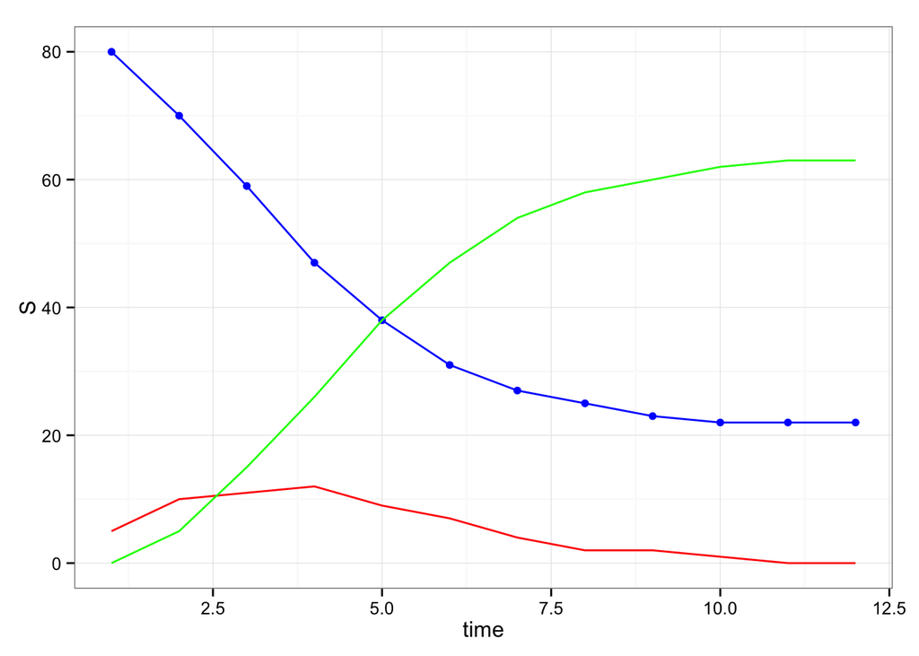

Set up the required arguments to run the JAGS model

```r
data <- list(obs = sim$Iobs,
             pop = pop,
             numobs = nrow(sim),
             r0 = r0)

inits <- list(list(
  I = sim$I*1,
  effpropS = effpropS - 0.1,
  effpropI = effpropI - 0.15,
  beta = beta + .05,
  reporting = reporting),
list(
  I = sim$I*1 + 1,
  effpropS = effpropS - 0.1,
  effpropI = effpropI + 0.2,
  beta = beta + .1,
  reporting = reporting),
list(
  I = sim$I*1 + 2,
  effpropS = effpropS,
  effpropI = effpropI,
  beta = beta - .008,
  reporting = reporting)
)

params = c("beta",
           "effpropS",
           "effpropI",
           "reporting")

#rjags::set.factory("bugs::Conjugate", FALSE, type="sampler")
```

Create the model and examine the MCMC algorithms that JAGS will use to sample

```r
cbjagsmodel <- jags.model(data = data,
               inits = inits,
               file = "CB.bug",
               n.chains = length(inits))
```

```
##    Graph Size: 84
##
```

```r
list.samplers(cbjagsmodel)
```

```
## $ShiftedCount
## [1] "I[12]"
##
## $DiscreteSlicer
## [1] "I[11]"
##
## $DiscreteSlicer
## [1] "I[10]"
##
## $DiscreteSlicer
## [1] "I[9]"
##
## $DiscreteSlicer
## [1] "I[8]"
##
## $DiscreteSlicer
## [1] "I[7]"
##
## $DiscreteSlicer
## [1] "I[6]"
##
## $DiscreteSlicer
## [1] "I[5]"
##
## $DiscreteSlicer
## [1] "I[4]"
##
## $DiscreteSlicer
## [1] "I[3]"
##
## $DiscreteSlicer
## [1] "I[2]"
##
## $DiscreteSlicer
## [1] "I[1]"
##
## $DiscreteSlicer
## [1] "S[1]"
##
## $RealSlicer
## [1] "beta"
##
## $ConjugateBeta
## [1] "effpropI"
##
## $ConjugateBeta
## [1] "effpropS"
##
## $ConjugateBeta
## [1] "reporting"
```

Run some chains (could use coda::coda.samples from cbjagsmodel but here we will just run jags())

```r
coda.samples(cbjagsmodel, c("beta", "effpropS", "effpropI", "reporting"), 1000)
```

Run through jags

```r
jagstime <- system.time(cbjags <- jags(data = data,
               inits = inits,
               param = params,
               model.file = "CB.bug",
               n.iter = 11000,
               n.burnin = 1000,
               n.thin = 20,
               n.chains = length(inits)))
```

```
## module glm loaded
```

```
##    Graph Size: 84
##
```

```r
cbjags
```

```
## Inference for Bugs model at "CB.bug", fit using jags,
##  3 chains, each with 11000 iterations (first 1000 discarded), n.thin = 20
##  n.sims = 1500 iterations saved
##           mu.vect sd.vect   2.5%    25%    50%    75%  97.5%  Rhat n.eff
## beta        0.022   0.007  0.012  0.017  0.020  0.025  0.039 1.002  1200
## effpropI    0.391   0.270  0.035  0.155  0.331  0.589  0.943 1.003   730
## effpropS    0.820   0.128  0.506  0.753  0.855  0.918  0.974 1.006   430
## reporting   0.481   0.119  0.298  0.391  0.464  0.553  0.762 1.005   370
## deviance   29.965   3.350 23.533 27.913 29.820 32.034 37.025 1.008   290
##
## For each parameter, n.eff is a crude measure of effective sample size,
## and Rhat is the potential scale reduction factor (at convergence, Rhat=1).
##
## DIC info (using the rule, pD = var(deviance)/2)
## pD = 5.6 and DIC = 35.5
## DIC is an estimate of expected predictive error (lower deviance is better).
```

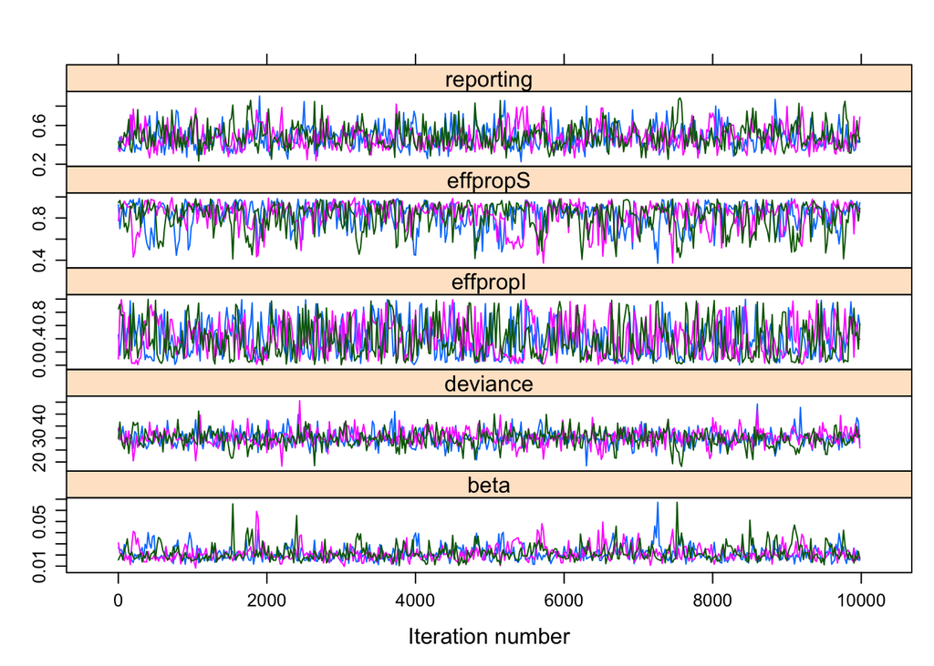

```r
xyplot(as.mcmc(cbjags))
```

##### 1.2 Build the NIMLE model

```r
source('nimCB.R')
```

Set up the model. Here we need: Constants, Data, Initial Values, NIMBLE model object

```r
nimCBdata <- list(obs = sim$Iobs)

nimCBcon <- list(numobs = numobs, pop = pop, r0 = r0)

nimCBinits <- list(I = sim$I,
                   effpropS = effpropS,
                   effpropI = effpropI,
                   beta = beta,
                   reporting = reporting,
                   s0 = s0)

nimtimevec[1] <- system.time(CBout <- nimbleModel(code = nimcode,
                         name = 'CBout',
                         constants = nimCBcon,
                         data = nimCBdata,
                         inits = nimCBinits))[3]
```

```
## defining model...
## building model...
## setting data and initial values...
## checking model...   (use nimbleModel(..., check = FALSE) to skip model check)
## model building finished
```

##### 1.2.1 Model exploration/conversion

```r
CBout$getNodeNames()
```

```
##  [1] "reporting"            "effpropS"             "effpropI"
##  [4] "beta"                 "R[1]"                 "s0"
##  [7] "lifted_d100_minus_s0" "S[1]"                 "I[1]"
## [10] "pSI[1]"               "obs[1]"               "R[2]"
## [13] "I[2]"                 "S[2]"                 "R[3]"
## [16] "pSI[2]"               "obs[2]"               "I[3]"
## [19] "S[3]"                 "R[4]"                 "pSI[3]"
## [22] "obs[3]"               "I[4]"                 "S[4]"
## [25] "R[5]"                 "pSI[4]"               "obs[4]"
## [28] "I[5]"                 "S[5]"                 "R[6]"
## [31] "pSI[5]"               "obs[5]"               "I[6]"
## [34] "S[6]"                 "R[7]"                 "pSI[6]"
## [37] "obs[6]"               "I[7]"                 "S[7]"
## [40] "R[8]"                 "pSI[7]"               "obs[7]"
## [43] "I[8]"                 "S[8]"                 "R[9]"
## [46] "pSI[8]"               "obs[8]"               "I[9]"
## [49] "S[9]"                 "R[10]"                "pSI[9]"
## [52] "obs[9]"               "I[10]"                "S[10]"
## [55] "R[11]"                "pSI[10]"              "obs[10]"
## [58] "I[11]"                "S[11]"                "R[12]"
## [61] "pSI[11]"              "obs[11]"              "I[12]"
## [64] "S[12]"                "pSI[12]"              "obs[12]"
```

You can examine a single specific node using:

```r
CBout[['I[2]']]
```

```
## [1] 10
```

```r
CBout$obs
```

```
##  [1] 1 5 6 4 5 4 2 2 0 1 0 0
```

nimbleModel does its best to initialize a model, but let’s say you want to re-initialize I.

```r
simulate(CBout, 'I') # using the current beta -- if we update beta to a new value this will change
CBout$I
```

```
##  [1]  7 10 14  9 11  7  1  2  2  0  1  0
```

And take a look at the log-prob

```r
calculate(CBout, "I")
```

```
## [1] -21.70036
```

```r
CBout$logProb_I
```

```
##  [1] -2.9086403 -2.3671034 -2.1998297 -2.3751669 -2.0406554 -1.8454856
##  [7] -2.8344862 -1.2710398 -1.6833944 -0.9293245 -1.2452374  0.0000000
```

```r
I2lp <- CBout$nodes[['I[2]']]$calculate()
I2lp
```

```
## [1] -2.367103
```

or Calculate new log probabilities after updating I

```r
CBout$obs
```

```
##  [1] 1 5 6 4 5 4 2 2 0 1 0 0
```

```r
getLogProb(CBout, 'obs')
```

```
## [1] -14.00589
```

```r
calculate(CBout, CBout$getDependencies(c("obs")))
```

```
## [1] -Inf
```

```r
CBout$logProb_obs
```

```
##  [1] -2.9061201 -1.4020427 -1.6966935 -1.4020427 -1.4890541 -1.2966822
##  [7]       -Inf -1.3862944 -1.3862944       -Inf -0.6931472  0.0000000
```

We can also look at the dependencies to make sense of what is going on

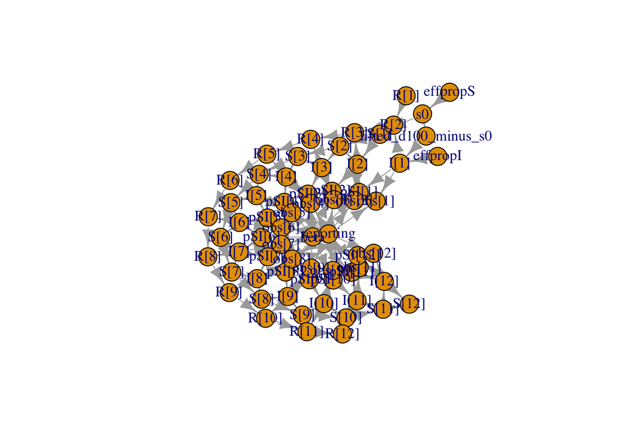

```r
par(mfrow = c(1,1))
plot(CBout$graph)
```

```r
CBout$getDependencies(c("beta"))
```

```
##  [1] "beta"    "pSI[1]"  "I[2]"    "pSI[2]"  "I[3]"    "pSI[3]"  "I[4]"
##  [8] "pSI[4]"  "I[5]"    "pSI[5]"  "I[6]"    "pSI[6]"  "I[7]"    "pSI[7]"
## [15] "I[8]"    "pSI[8]"  "I[9]"    "pSI[9]"  "I[10]"   "pSI[10]" "I[11]"
## [22] "pSI[11]" "I[12]"   "pSI[12]"
```

```r
CBout$getDependencies(c("beta"), determOnly = TRUE)
```

```
##  [1] "pSI[1]"  "pSI[2]"  "pSI[3]"  "pSI[4]"  "pSI[5]"  "pSI[6]"  "pSI[7]"
##  [8] "pSI[8]"  "pSI[9]"  "pSI[10]" "pSI[11]" "pSI[12]"
```

We will return to nimbleFunctions later – but here is an initial example nimbleFunction that will simulate multiple values for a designated set of nodes and calculate every part of the model that depends on them

```r
simNodesMany <- nimbleFunction( setup = function(model, nodes) {
        mv <- modelValues(model)
        deps <- model$getDependencies(nodes)
        allNodes <- model$getNodeNames()
},
run = function(n = integer()) {
  resize(mv, n)
  for(i in 1:n) {
            simulate(model, nodes)
            calculate(model, deps)
            copy(from = model, nodes = allNodes,
to = mv, rowTo = i, logProb = TRUE) }
})
```

```r
outI <- simNodesMany(CBout, "I")

outI$run(1)

outI$mv[["logProb_obs"]]
```

```
## [[1]]
##  [1] -1.3862944 -3.4657359 -1.4890541 -2.1132084 -1.6432048 -1.2966822
##  [7] -1.8075078 -0.9808293  0.0000000 -0.6931472  0.0000000  0.0000000
```

##### 1.2.2 Compile the C++ model, build the MCMC and Run

```r
nimtimevec[2] <- system.time(CBoutC <- compileNimble(CBout))[3]
```

Configure the MCMC with the default options (we will return to customizing this setup later)

```r
nimtimevec[3] <- system.time(CBoutSpec <- configureMCMC(CBout, print = TRUE))[3]
```

```
## [1] RW sampler: reporting,  adaptive: TRUE,  adaptInterval: 200,  scale: 1
## [2] RW sampler: effpropS,  adaptive: TRUE,  adaptInterval: 200,  scale: 1
## [3] RW sampler: effpropI,  adaptive: TRUE,  adaptInterval: 200,  scale: 1
## [4] RW sampler: beta,  adaptive: TRUE,  adaptInterval: 200,  scale: 1
## [5] slice sampler: s0,  adaptive: TRUE,  adaptInterval: 200,  sliceWidth: 1,  sliceMaxSteps: 100
## [6] slice sampler: I[1],  adaptive: TRUE,  adaptInterval: 200,  sliceWidth: 1,  sliceMaxSteps: 100
## [7] slice sampler: I[2],  adaptive: TRUE,  adaptInterval: 200,  sliceWidth: 1,  sliceMaxSteps: 100
## [8] slice sampler: I[3],  adaptive: TRUE,  adaptInterval: 200,  sliceWidth: 1,  sliceMaxSteps: 100
## [9] slice sampler: I[4],  adaptive: TRUE,  adaptInterval: 200,  sliceWidth: 1,  sliceMaxSteps: 100
## [10] slice sampler: I[5],  adaptive: TRUE,  adaptInterval: 200,  sliceWidth: 1,  sliceMaxSteps: 100
## [11] slice sampler: I[6],  adaptive: TRUE,  adaptInterval: 200,  sliceWidth: 1,  sliceMaxSteps: 100
## [12] slice sampler: I[7],  adaptive: TRUE,  adaptInterval: 200,  sliceWidth: 1,  sliceMaxSteps: 100
## [13] slice sampler: I[8],  adaptive: TRUE,  adaptInterval: 200,  sliceWidth: 1,  sliceMaxSteps: 100
## [14] slice sampler: I[9],  adaptive: TRUE,  adaptInterval: 200,  sliceWidth: 1,  sliceMaxSteps: 100
## [15] slice sampler: I[10],  adaptive: TRUE,  adaptInterval: 200,  sliceWidth: 1,  sliceMaxSteps: 100
## [16] slice sampler: I[11],  adaptive: TRUE,  adaptInterval: 200,  sliceWidth: 1,  sliceMaxSteps: 100
## [17] slice sampler: I[12],  adaptive: TRUE,  adaptInterval: 200,  sliceWidth: 1,  sliceMaxSteps: 100
```

Add chain monitors for the parameters of interest and add thinning

```r
CBoutSpec$addMonitors(c("beta", "effpropS", "effpropI", "reporting"))
```

```
## thin = 1: reporting, effpropS, effpropI, beta
```

```r
CBoutSpec$setThin(20)
```

```
## thin = 20: reporting, effpropS, effpropI, beta
```

Build the MCMC

```r
nimtimevec[4] <- system.time(CBoutMCMC <- buildMCMC(CBoutSpec))[3]

nimtimevec[5] <- system.time(CBoutMCMC <- compileNimble(CBoutMCMC, project = CBout, resetFunctions = TRUE))[3]
```

```r
niter <- 11000

set.seed(0)
nimtimevec[6] <- system.time(CBoutMCMC$run(niter))[3]
```

```
## warning: problem initializing stochastic node, logProb less than -1e12
```

```r
  # mcmc$run(niter, reset = FALSE) can be used to add more iterations
```

Quick peek at time required. Below we will take a look at efficiency using a convenient coda function

Gross time required

```r
jagstime[3]
```

```
## elapsed
##  11.216
```

```r
sum(nimtimevec[1:6], na.rm = TRUE)
```

```
## [1] 18.763
```

```r
nimtimevec[6]
```

```
## [1] 0.984
```

Efficiency (Net time in a sense)

```r
samples <- as.matrix(CBoutMCMC$mvSamples)

head(samples)
```

```
##            beta   effpropI  effpropS reporting
## [1,] 0.02000000 0.10177476 0.8000000 0.5000000
## [2,] 0.02000000 0.17117041 0.8344718 0.4494027
## [3,] 0.02000000 0.27383622 0.7354812 0.5960751
## [4,] 0.02000000 0.26997867 0.7354812 0.5559008
## [5,] 0.02000000 0.02263745 0.7487252 0.5268280
## [6,] 0.01683664 0.27080943 0.8114301 0.6138359
```

```r
jags_eff <- effectiveSize(as.mcmc.list(as.mcmc(cbjags))) / nimtimevec[1]
nim_eff <- effectiveSize(as.mcmc.list(as.mcmc(samples))) / nimtimevec[6]

jags_eff
```

```
##      beta  deviance  effpropI  effpropS reporting
##  576.2638 1068.2372  694.4240  414.1345  646.1680
```

```r
nim_eff
```

```
##      beta  effpropI  effpropS reporting
## 124.84105 147.18720  85.61667 222.36940
```

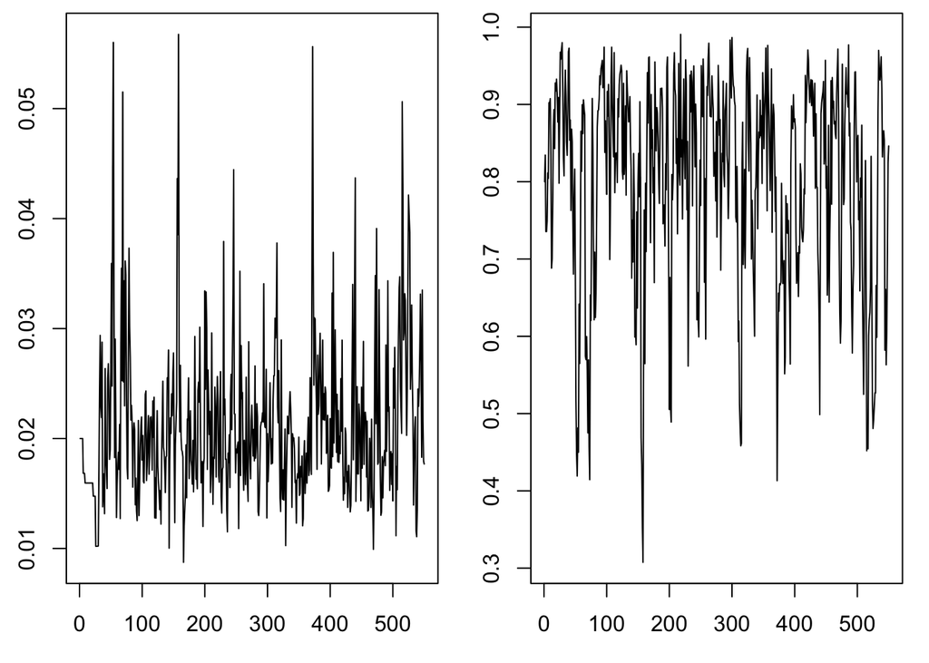

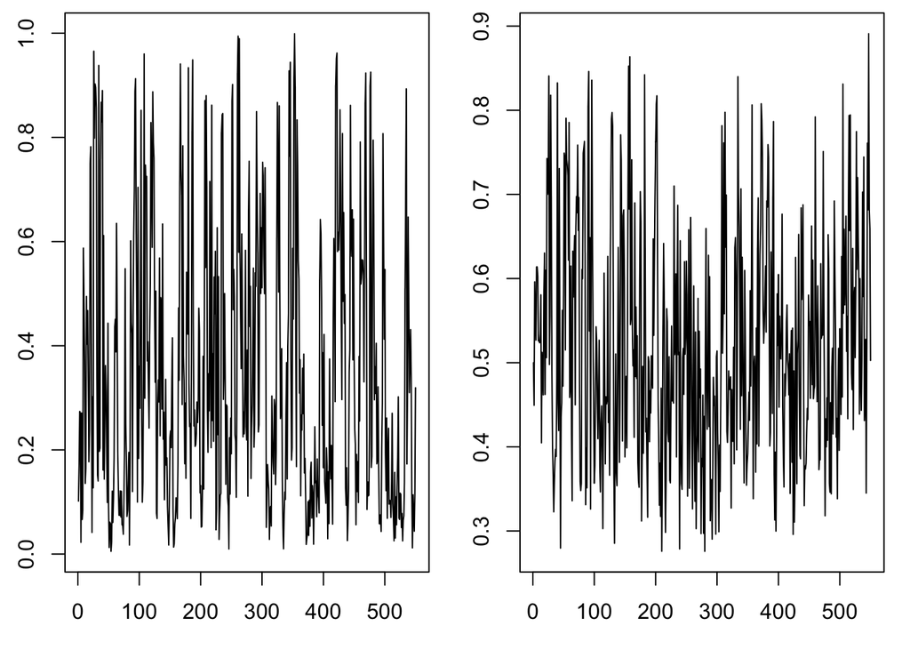

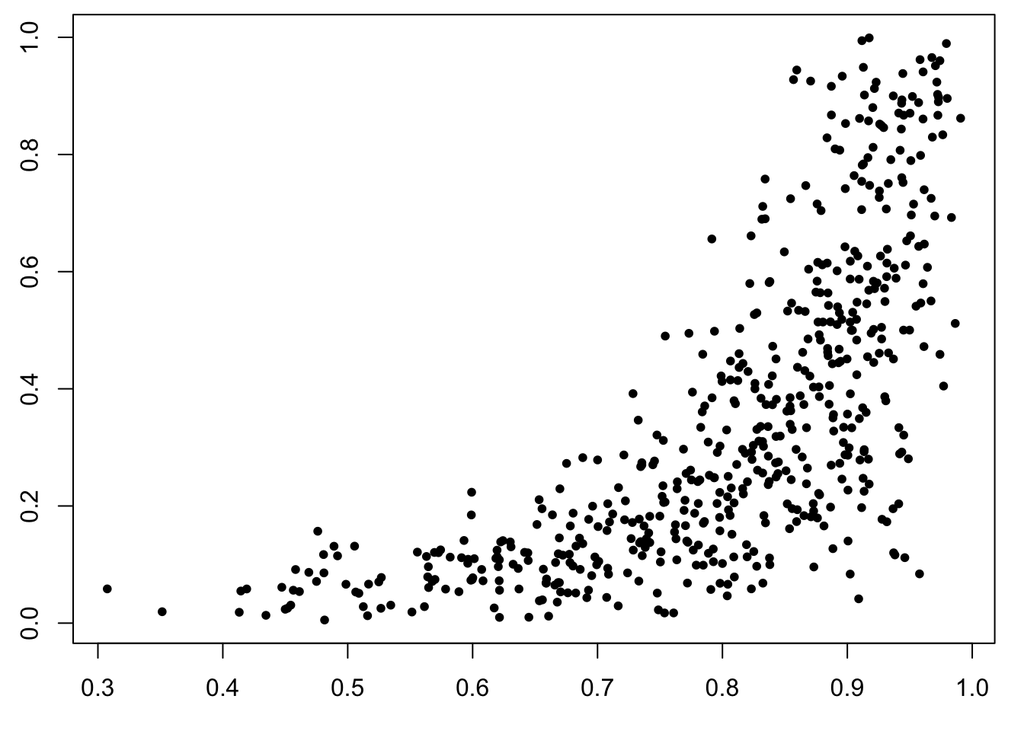

Save these points for later

```r
  def_effS <- samples[ , 'effpropS']
  def_effI <- samples[ , 'effpropI']
```

Look at the correlation in the chains

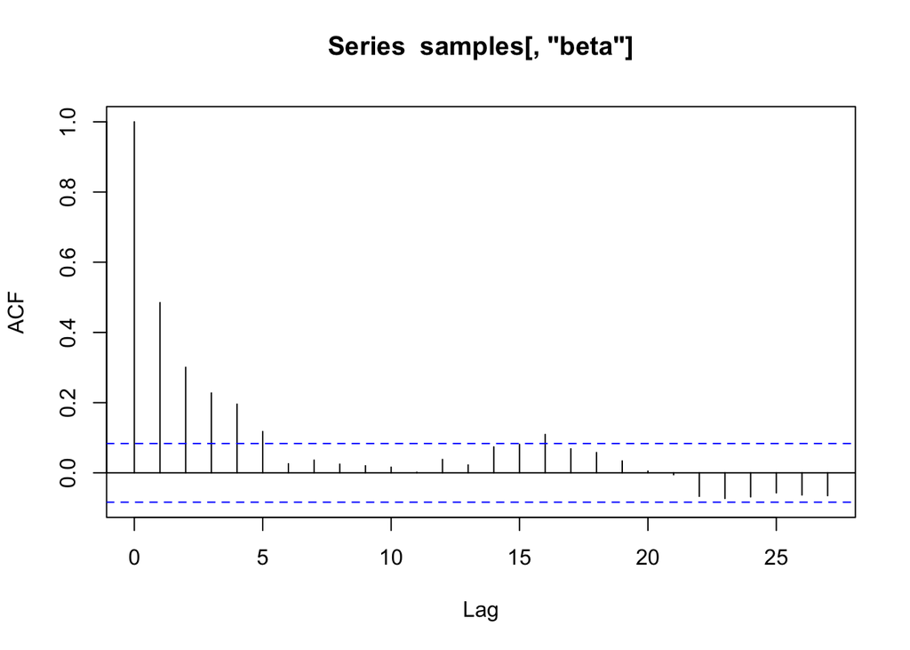

```r
  acf(samples[, "beta"])
```

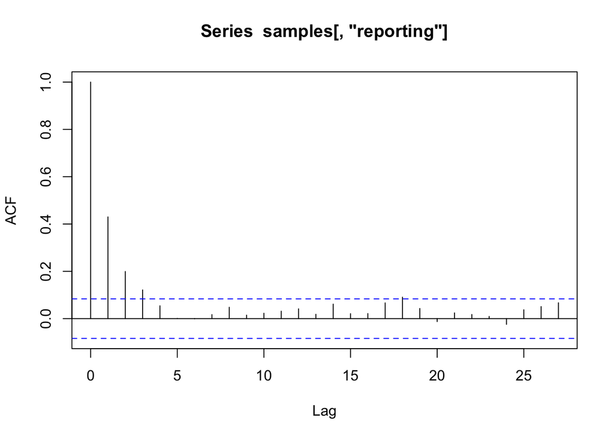

```r
  acf(samples[, "reporting"])
```

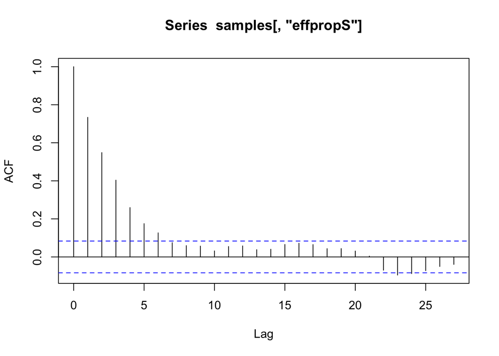

```r
  acf(samples[, "effpropS"])
```

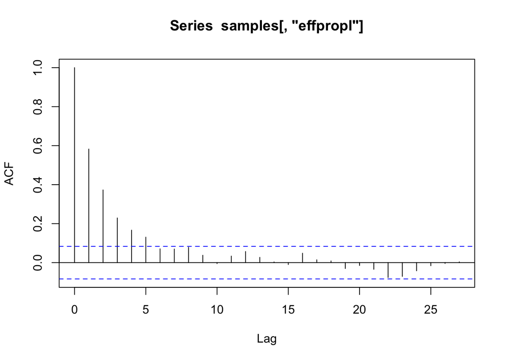

```r
  acf(samples[, "effpropI"])
```

##### 1.2.3 Small MCMC specification adjustment

A few undesirable results here… we can add a block sampler to decrease correlation

Take a look at the samplers being used

```r
CBoutSpec$getSamplers()
```

```
## [1]  RW sampler: reporting,  adaptive: TRUE,  adaptInterval: 200,  scale: 1
## [2]  RW sampler: effpropS,  adaptive: TRUE,  adaptInterval: 200,  scale: 1
## [3]  RW sampler: effpropI,  adaptive: TRUE,  adaptInterval: 200,  scale: 1
## [4]  RW sampler: beta,  adaptive: TRUE,  adaptInterval: 200,  scale: 1
## [5]  slice sampler: s0,  adaptive: TRUE,  adaptInterval: 200,  sliceWidth: 1,  sliceMaxSteps: 100
## [6]  slice sampler: I[1],  adaptive: TRUE,  adaptInterval: 200,  sliceWidth: 1,  sliceMaxSteps: 100
## [7]  slice sampler: I[2],  adaptive: TRUE,  adaptInterval: 200,  sliceWidth: 1,  sliceMaxSteps: 100
## [8]  slice sampler: I[3],  adaptive: TRUE,  adaptInterval: 200,  sliceWidth: 1,  sliceMaxSteps: 100
## [9]  slice sampler: I[4],  adaptive: TRUE,  adaptInterval: 200,  sliceWidth: 1,  sliceMaxSteps: 100
## [10] slice sampler: I[5],  adaptive: TRUE,  adaptInterval: 200,  sliceWidth: 1,  sliceMaxSteps: 100
## [11] slice sampler: I[6],  adaptive: TRUE,  adaptInterval: 200,  sliceWidth: 1,  sliceMaxSteps: 100
## [12] slice sampler: I[7],  adaptive: TRUE,  adaptInterval: 200,  sliceWidth: 1,  sliceMaxSteps: 100
## [13] slice sampler: I[8],  adaptive: TRUE,  adaptInterval: 200,  sliceWidth: 1,  sliceMaxSteps: 100
## [14] slice sampler: I[9],  adaptive: TRUE,  adaptInterval: 200,  sliceWidth: 1,  sliceMaxSteps: 100
## [15] slice sampler: I[10],  adaptive: TRUE,  adaptInterval: 200,  sliceWidth: 1,  sliceMaxSteps: 100
## [16] slice sampler: I[11],  adaptive: TRUE,  adaptInterval: 200,  sliceWidth: 1,  sliceMaxSteps: 100
## [17] slice sampler: I[12],  adaptive: TRUE,  adaptInterval: 200,  sliceWidth: 1,  sliceMaxSteps: 100
```

```r
CBoutSpec$addSampler(target = c('effpropS', 'effpropI'), type = 'RW_block',
                      control = list(adaptInterval = 10000))
```

```
## [18] RW_block sampler: effpropS, effpropI,  adaptive: TRUE,  adaptScaleOnly: FALSE,  adaptInterval: 10000,  scale: 1,  propCov: identity
```

```r
CBoutSpec$setThin(30)
```

```
## thin = 30: reporting, effpropS, effpropI, beta
```

```r
CBoutMCMC <- buildMCMC(CBoutSpec)
```

```r
CBoutMCMC <- compileNimble(CBoutMCMC, project  = CBout, resetFunctions = TRUE)
```

```r
CBoutMCMC$run(30000)
```

```r
samplesNew <- as.matrix(CBoutMCMC$mvSamples)
```

Check for an imporvement

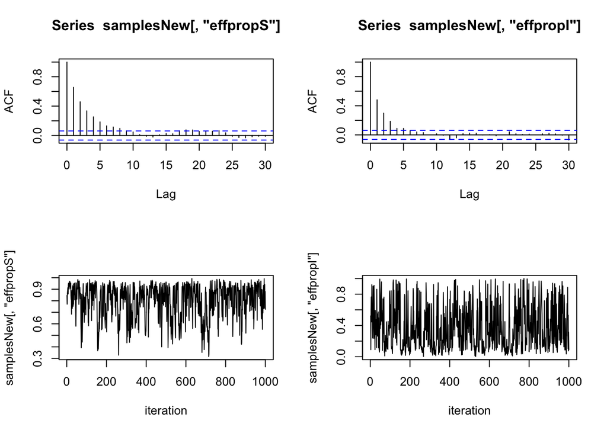

```r
  par(mfrow = c(2,2))
  acf(samplesNew[, "effpropS"])
  acf(samplesNew[, "effpropI"])
  plot(samplesNew[ , 'effpropS'], type = 'l', xlab = 'iteration')
  plot(samplesNew[ , 'effpropI'], type = 'l', xlab = 'iteration')
```

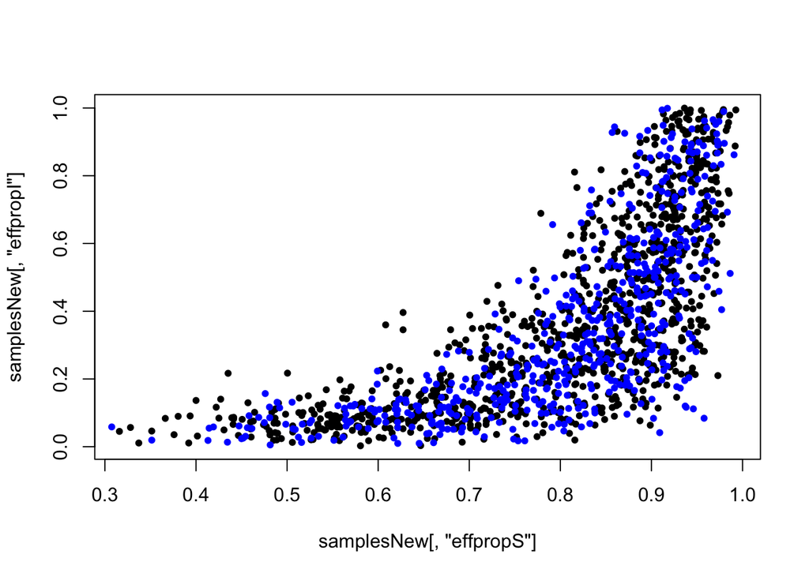

```r
  par(mfrow = c(1,1))
  plot(samplesNew[ , 'effpropS'], samplesNew[ , 'effpropI'], pch = 20)
  points(def_effS, def_effI, pch = 20, col = "blue")
```

Well that didn’t do anything…

NIMBLE allows for specification of samplers by parameter or node by node (NIMBLE included or user created)

```r
CBout <- nimbleModel(code = nimcode,
                         name = 'CBout',
                         constants = nimCBcon,
                         data = nimCBdata,
                         inits = nimCBinits)
```

```
## defining model...
## building model...
## setting data and initial values...
## checking model...   (use nimbleModel(..., check = FALSE) to skip model check)
## model building finished
```

```r
CBoutC <- compileNimble(CBout)

CBoutSpec <- configureMCMC(CBout, print = TRUE)
```

```
## [1] RW sampler: reporting,  adaptive: TRUE,  adaptInterval: 200,  scale: 1
## [2] RW sampler: effpropS,  adaptive: TRUE,  adaptInterval: 200,  scale: 1
## [3] RW sampler: effpropI,  adaptive: TRUE,  adaptInterval: 200,  scale: 1
## [4] RW sampler: beta,  adaptive: TRUE,  adaptInterval: 200,  scale: 1
## [5] slice sampler: s0,  adaptive: TRUE,  adaptInterval: 200,  sliceWidth: 1,  sliceMaxSteps: 100
## [6] slice sampler: I[1],  adaptive: TRUE,  adaptInterval: 200,  sliceWidth: 1,  sliceMaxSteps: 100
## [7] slice sampler: I[2],  adaptive: TRUE,  adaptInterval: 200,  sliceWidth: 1,  sliceMaxSteps: 100
## [8] slice sampler: I[3],  adaptive: TRUE,  adaptInterval: 200,  sliceWidth: 1,  sliceMaxSteps: 100
## [9] slice sampler: I[4],  adaptive: TRUE,  adaptInterval: 200,  sliceWidth: 1,  sliceMaxSteps: 100
## [10] slice sampler: I[5],  adaptive: TRUE,  adaptInterval: 200,  sliceWidth: 1,  sliceMaxSteps: 100
## [11] slice sampler: I[6],  adaptive: TRUE,  adaptInterval: 200,  sliceWidth: 1,  sliceMaxSteps: 100
## [12] slice sampler: I[7],  adaptive: TRUE,  adaptInterval: 200,  sliceWidth: 1,  sliceMaxSteps: 100
## [13] slice sampler: I[8],  adaptive: TRUE,  adaptInterval: 200,  sliceWidth: 1,  sliceMaxSteps: 100
## [14] slice sampler: I[9],  adaptive: TRUE,  adaptInterval: 200,  sliceWidth: 1,  sliceMaxSteps: 100
## [15] slice sampler: I[10],  adaptive: TRUE,  adaptInterval: 200,  sliceWidth: 1,  sliceMaxSteps: 100
## [16] slice sampler: I[11],  adaptive: TRUE,  adaptInterval: 200,  sliceWidth: 1,  sliceMaxSteps: 100
## [17] slice sampler: I[12],  adaptive: TRUE,  adaptInterval: 200,  sliceWidth: 1,  sliceMaxSteps: 100
```

```r
CBoutSpec$addMonitors(c("beta", "effpropS", "effpropI", "reporting"))
```

```
## thin = 1: reporting, effpropS, effpropI, beta
```

```r
CBoutSpec$setThin(20)
```

```
## thin = 20: reporting, effpropS, effpropI, beta
```

```r
CBoutSpec$removeSamplers(c("beta", "effpropS", "effpropI", "reporting"), print = TRUE)
```

```
## [1]  slice sampler: s0,  adaptive: TRUE,  adaptInterval: 200,  sliceWidth: 1,  sliceMaxSteps: 100
## [2]  slice sampler: I[1],  adaptive: TRUE,  adaptInterval: 200,  sliceWidth: 1,  sliceMaxSteps: 100
## [3]  slice sampler: I[2],  adaptive: TRUE,  adaptInterval: 200,  sliceWidth: 1,  sliceMaxSteps: 100
## [4]  slice sampler: I[3],  adaptive: TRUE,  adaptInterval: 200,  sliceWidth: 1,  sliceMaxSteps: 100
## [5]  slice sampler: I[4],  adaptive: TRUE,  adaptInterval: 200,  sliceWidth: 1,  sliceMaxSteps: 100
## [6]  slice sampler: I[5],  adaptive: TRUE,  adaptInterval: 200,  sliceWidth: 1,  sliceMaxSteps: 100
## [7]  slice sampler: I[6],  adaptive: TRUE,  adaptInterval: 200,  sliceWidth: 1,  sliceMaxSteps: 100
## [8]  slice sampler: I[7],  adaptive: TRUE,  adaptInterval: 200,  sliceWidth: 1,  sliceMaxSteps: 100
## [9]  slice sampler: I[8],  adaptive: TRUE,  adaptInterval: 200,  sliceWidth: 1,  sliceMaxSteps: 100
## [10] slice sampler: I[9],  adaptive: TRUE,  adaptInterval: 200,  sliceWidth: 1,  sliceMaxSteps: 100
## [11] slice sampler: I[10],  adaptive: TRUE,  adaptInterval: 200,  sliceWidth: 1,  sliceMaxSteps: 100
## [12] slice sampler: I[11],  adaptive: TRUE,  adaptInterval: 200,  sliceWidth: 1,  sliceMaxSteps: 100
## [13] slice sampler: I[12],  adaptive: TRUE,  adaptInterval: 200,  sliceWidth: 1,  sliceMaxSteps: 100
```

```r
CBoutSpec$addSampler("beta", type = "slice", print = TRUE)
```

```
## [14] slice sampler: beta,  adaptive: TRUE,  adaptInterval: 200,  sliceWidth: 1,  sliceMaxSteps: 100
```

```r
CBoutSpec$addSampler("effpropS", type = "slice", print = TRUE)
```

```
## [15] slice sampler: effpropS,  adaptive: TRUE,  adaptInterval: 200,  sliceWidth: 1,  sliceMaxSteps: 100
```

```r
CBoutSpec$addSampler("effpropI", type = "slice", print = TRUE)
```

```
## [16] slice sampler: effpropI,  adaptive: TRUE,  adaptInterval: 200,  sliceWidth: 1,  sliceMaxSteps: 100
```

```r
CBoutSpec$addSampler("reporting", type = "slice", print = TRUE)
```

```
## [17] slice sampler: reporting,  adaptive: TRUE,  adaptInterval: 200,  sliceWidth: 1,  sliceMaxSteps: 100
```

```r
CBoutMCMC <- buildMCMC(CBoutSpec)
CBoutMCMC <- compileNimble(CBoutMCMC, project  = CBout, resetFunctions = TRUE)
```

```r
nimtimevec[7] <- system.time(CBoutMCMC$run(30000))[3]
samplesblock <- as.matrix(CBoutMCMC$mvSamples)
nim_eff <- effectiveSize(as.mcmc.list(as.mcmc(samplesblock))) / nimtimevec[7]
nim_eff
```

```
##      beta  effpropI  effpropS reporting
##  162.3696  169.6129  133.1738  279.6492
```

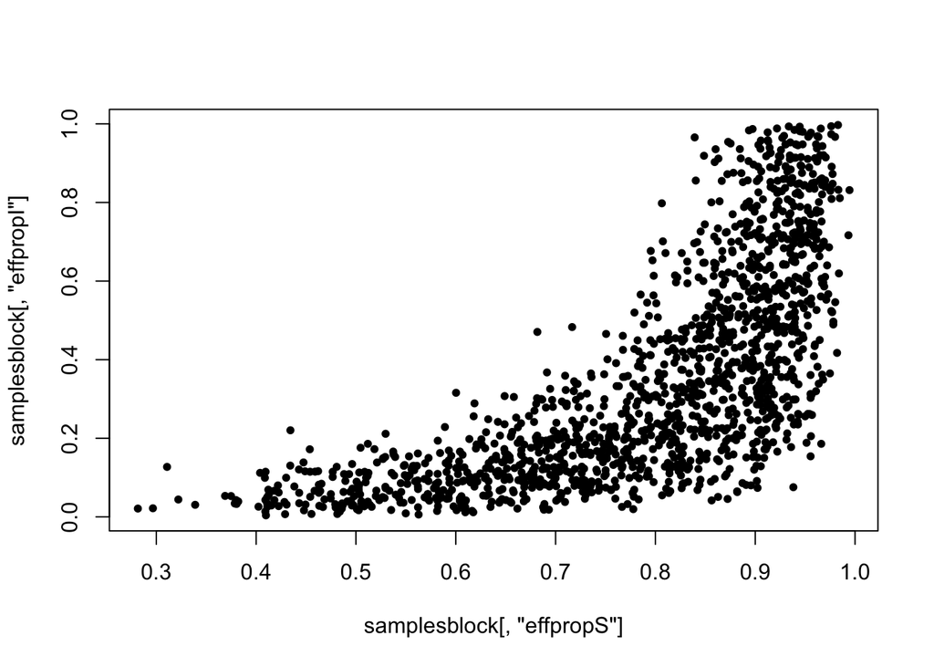

```r
  par(mfrow = c(1,1))
  plot(samplesblock[ , 'effpropS'], samplesblock[ , 'effpropI'], pch = 20)
```

##### 1.3 Compare the JAGS and NIMBLE results

We can also compare the NIMBLE model simultaneously with the JAGS model using MCMCsuite()

Be warned: running this code with “makePlot = TRUE” will produce about 6-8 graphs which will all pop up in separate windows!

```r
nimcb <- MCMCsuite(code = nimcode,
                   data = nimCBdata,
                   inits = nimCBinits,
                   constants = nimCBcon,
                   MCMCs = c("jags", "nimble"),
                   monitors = c("beta", "reporting", "effpropS", "effpropI"),
                   niter = 12000,
                   calculateEfficiency = TRUE,
                   makePlot = FALSE,
                   savePlot = FALSE)
```

```
## defining model...
## building model...
## setting data and initial values...
## checking model...   (use nimbleModel(..., check = FALSE) to skip model check)
## model building finished
```

```
##    Graph Size: 83
##
```

```r
  nimcb$summary
```

```
## , , beta
##
##              mean     median          sd   CI95_low   CI95_upp     n
## jags   0.02235506 0.01993475 0.009290924 0.01192969 0.04930857 10000
## nimble 0.02238331 0.02026432 0.008585741 0.01212697 0.04593279 10000
##             ess efficiency
## jags   167.7002   54.80399
## nimble  83.1905   81.32014
##
## , , reporting
##
##             mean    median        sd  CI95_low  CI95_upp     n      ess
## jags   0.5285802 0.5041255 0.1423119 0.3107020 0.8466422 10000 315.0978
## nimble 0.5291161 0.5031207 0.1402128 0.3107321 0.8428592 10000 223.0523
##        efficiency
## jags     102.9732
## nimble   218.0375
##
## , , effpropS
##
##             mean    median        sd  CI95_low  CI95_upp     n       ess
## jags   0.7926881 0.8382013 0.1542259 0.4203824 0.9733032 10000 132.56992
## nimble 0.7917268 0.8326756 0.1502838 0.4371907 0.9729178 10000  52.59819
##        efficiency
## jags     43.32350
## nimble   51.41563
##
## , , effpropI
##
##             mean    median        sd   CI95_low  CI95_upp     n      ess
## jags   0.3699944 0.3031987 0.2737106 0.02785579 0.9439729 10000 335.4384
## nimble 0.3646788 0.2788137 0.2803558 0.02503840 0.9535620 10000 118.3843
##        efficiency
## jags     109.6204
## nimble   115.7227
```

```r
  nimcb$efficiency
```

```
## $min
##     jags   nimble
## 43.32350 51.41563
##
## $mean
##      jags    nimble
##  77.68026 116.62397
```

```r
  nimcb$timing
```

```
##           jags         nimble nimble_compile
##          3.060          1.023         13.143
```

MCMCsuite allows for convenient specification of MCMC runs

```r
nimcb <- MCMCsuite(code = nimcode,
                   data = nimCBdata,
                   inits = nimCBinits,
                   constants = nimCBcon,
                   MCMCs = c("jags", "nimble", "autoBlock", "nimble_RW"),
                   monitors = c("beta", "reporting", "effpropS", "effpropI"),
                   niter = 12000,
                   burnin = 1000,
                #   thin = 10,
                   calculateEfficiency = TRUE,
                   makePlot = FALSE,
                   savePlot = FALSE)
```

```
## defining model...
## building model...
## setting data and initial values...
## checking model...   (use nimbleModel(..., check = FALSE) to skip model check)
## model building finished
```

```
##    Graph Size: 83
##
##
##
## Auto-Blocking summary:
##            mcmc     node     S    C Efficiency
## 1   All Blocked effpropS  8.31 0.98       8.51
## 2       Default       s0 72.83 0.82      88.55
## 3    All Scalar       s0 72.83 0.82      89.04
## 4 Auto-Blocking       s0 72.83 0.82      89.14
##
## Auto-Blocking converged on all scalar (univariate) sampling
```

```r
  nimcb$summary
```

```
## , , beta
##
##                 mean     median          sd   CI95_low   CI95_upp     n
## jags      0.02202538 0.01995902 0.008173133 0.01230835 0.04470518 11000
## nimble    0.02326376 0.02142373 0.008277899 0.01270738 0.04529219 11000
## autoBlock 0.02223389 0.02005801 0.008438087 0.01216501 0.04680976 11000
## nimble_RW 0.02150700 0.01996704 0.006958702 0.01215994 0.03994221 11000
##                 ess efficiency
## jags      214.98290   71.54173
## nimble    135.42591  134.08506
## autoBlock  79.04899   80.74463
## nimble_RW 205.95218  207.61309
##
## , , reporting
##
##                mean    median        sd  CI95_low  CI95_upp     n      ess
## jags      0.5263296 0.5046281 0.1396932 0.3113519 0.8447523 11000 424.0524
## nimble    0.5329994 0.5199607 0.1360280 0.3148980 0.8296261 11000 236.1914
## autoBlock 0.5119445 0.4902637 0.1369659 0.3064950 0.8396076 11000 234.9167
## nimble_RW 0.5217788 0.5046228 0.1349471 0.3102448 0.8156944 11000 253.4517
##           efficiency
## jags        141.1156
## nimble      233.8529
## autoBlock   239.9557
## nimble_RW   255.4957
##
## , , effpropS
##
##                mean    median        sd  CI95_low  CI95_upp     n
## jags      0.7951436 0.8388926 0.1474004 0.4399434 0.9711306 11000
## nimble    0.7703934 0.7981826 0.1530485 0.4560266 0.9687040 11000
## autoBlock 0.8083018 0.8543280 0.1459840 0.4368252 0.9728792 11000
## nimble_RW 0.8039048 0.8491852 0.1389703 0.4762293 0.9671822 11000
##                 ess efficiency
## jags      161.89177   53.87413
## nimble     77.29572   76.53042
## autoBlock  66.72764   68.15897
## nimble_RW  79.77536   80.41871
##
## , , effpropI
##
##                mean    median        sd   CI95_low  CI95_upp     n
## jags      0.3637943 0.2930367 0.2679041 0.03010109 0.9406429 11000
## nimble    0.3320219 0.2334860 0.2714097 0.02644870 0.9429288 11000
## autoBlock 0.3918723 0.3311183 0.2816921 0.03272275 0.9575249 11000
## nimble_RW 0.3716978 0.3006341 0.2717469 0.02703861 0.9353198 11000
##                ess efficiency
## jags      314.8461   104.7741
## nimble    105.4101   104.3664
## autoBlock 146.2721   149.4097
## nimble_RW 164.0498   165.3727
```

```r
  nimcb$efficiency
```

```
## $min
##      jags    nimble autoBlock nimble_RW
##  53.87413  76.53042  68.15897  80.41871
##
## $mean
##      jags    nimble autoBlock nimble_RW
##  92.82639 137.20870 134.56726 177.22506
```

```r
  nimcb$timing
```

```
##           jags         nimble      autoBlock      nimble_RW nimble_compile
##          3.005          1.010          0.979          0.992         14.206
```

MCMCsuite can also be used to compare models written in STAN or… which we will see next week

##### Part 5:

NIMBLE Notes

**Truncation of distributions**  
• x ∼ N(0, sd = 10) T(0, a)$, or  
• x ∼ T(dnorm(0, sd = 10), 0, a),

• mu1 ~ dnorm(0, 1)  
• mu2 ~ dnorm(0, 1)  
• constraint_data ~ dconstraint( mu1 + mu2 > 0 )

**Lifted Nodes**  
• The use of link functions causes new nodes to be introduced  
• When distribution parameters are expressions, NIMBLE creates a new deterministic node that contains the expression for a given parameter

**logProb**  
• For each variable that contains at least one stochastic node, NIMBLE generates a model variable with the prefix “logProb”  
• Can be retrieved with getLogProb

**Choice of Samplers**  
1. If the node has no stochastic dependents, a predictive end sampler is assigned. The end sampling algorithm merely calls simulate on the particular node.  
2. The node is checked for presence of a conjugate relationship between its prior distribution and the distributions of its stochastic dependents. If it is determined to be in a conjugate relationship, then the corresponding conjugate (Gibbs) sampler is assigned.  
3. If the node is discrete-valued, then a slice sampler is assigned [5].  
4. If the node follows a multivariate distribution, then a RW block sampler is assigned for all elements. This is a Metropolis-Hastings adaptive random-walk sampler with a multivariate normal proposal [6].  
5. If none of the above criteria are satisfied, then a RW sampler is assigned. This is a Metropolis-Hastings adaptive random-walk sampler with a univariate normal proposal distribution.

**Missing Values**

```r
CBMiss <- CBout$newModel()
```

```
## setting data and initial values...
## checking model...   (use nimbleModel(..., check = FALSE) to skip model check)
```

```r
CBMiss$resetData()
CBDataNew <- nimCBdata
CBDataNew$obs[c(1, 3)] <- NA
CBMiss$setData(CBDataNew)
CBMissSpec <- configureMCMC(CBMiss)
CBMissSpec$addMonitors(c("obs", "beta", "effpropS", "effpropI", "reporting"))
```

```
## thin = 1: reporting, effpropS, effpropI, beta, obs
```

```r
CBMissMCMC <- buildMCMC(CBMissSpec)
CBCobj <- compileNimble(CBMiss, CBMissMCMC)
niter <- 1000
set.seed(0)
CBCobj$CBMissMCMC$run(niter)
```

```r
samples <- as.matrix(CBCobj$CBMissMCMC$mvSamples)
rbind(head(samples), tail(samples))
```

```
##               beta  effpropI  effpropS obs[1] obs[2] obs[3] obs[4] obs[5]
##         0.02000000 0.2000000 0.8000000      2      5      6      4      5
##         0.02000000 0.2000000 0.8000000      3      5      8      4      5
##         0.02000000 0.2000000 0.8000000      3      5      7      4      5
##         0.02000000 0.2000000 0.8274753      3      5      3      4      5
##         0.02000000 0.2000000 0.8448710      1      5      6      4      5
##         0.02000000 0.2000000 0.8448710      2      5      2      4      5
## [995,]  0.01430577 0.3728769 0.9059062      2      5      4      4      5
## [996,]  0.01430577 0.3728769 0.9059062      1      5      5      4      5
## [997,]  0.01430577 0.2934961 0.9059062      3      5      8      4      5
## [998,]  0.01430577 0.2934961 0.8973163      4      5      6      4      5
## [999,]  0.01430577 0.3886819 0.8973163      5      5      9      4      5
## [1000,] 0.01430577 0.3507792 0.8476990      3      5      7      4      5
##         obs[6] obs[7] obs[8] obs[9] obs[10] obs[11] obs[12] reporting
##              4      2      2      0       1       0       0 0.5000000
##              4      2      2      0       1       0       0 0.5000000
##              4      2      2      0       1       0       0 0.5000000
##              4      2      2      0       1       0       0 0.5253829
##              4      2      2      0       1       0       0 0.5253829
##              4      2      2      0       1       0       0 0.5253829
## [995,]       4      2      2      0       1       0       0 0.6150413
## [996,]       4      2      2      0       1       0       0 0.6150413
## [997,]       4      2      2      0       1       0       0 0.6150413
## [998,]       4      2      2      0       1       0       0 0.6150413
## [999,]       4      2      2      0       1       0       0 0.6150413
## [1000,]      4      2      2      0       1       0       0 0.6489087
```

**Multiple instances of the same model**  
Sometimes it is useful to have more than one copy of the same model. For example, nimbleFunctions are often bound to a particular model as a result of setup code.

```r
simpleCode <- nimbleCode({
for(i in 1:N) x[i] ~ dnorm(0, 1) })
## Return the model definition only, not a built model
simpleModelDefinition <- nimbleModel(simpleCode, constants = list(N = 10),
                                     returnDef = TRUE, check = FALSE)
```

```
## defining model...
```

```r
## Make one instance of the model
simpleModelCopy1 <- simpleModelDefinition$newModel(check = FALSE) ## Make another instance from the same definition
simpleModelCopy2 <- simpleModelDefinition$newModel(check = FALSE) ## Ask simpleModelCopy2 for another copy of itself
simpleModelCopy3 <- simpleModelCopy2$newModel(check = FALSE)
```